# Netflix TV Shows and Movies Data Frame Analysis

# 6 - 10 Queries

**Query # 1**

Which movies on Netflix have the longest duration?

```python
netflix_movie = netflix[netflix['type'] == 'MOVIE']
highest_duration = netflix_movie.sort_values(['runtime'], ascending = False).head(10)
highest_duration
```

|  | index | id | title | type | description | release_year | age_certification | runtime | imdb_id | imdb_score | imdb_votes |
| --- | --- | --- | --- | --- | --- | --- | --- | --- | --- | --- | --- |
| 24 | 24 | tm76557 | No Longer Kids | MOVIE | By coincidence, Ahmad discovers that his father, Ramada Al Sokkary has a love letter in his suit case, which reveals his love to a woman other than his mother. Ahmad tries with his brothers and sister… | 1979 | NA | 235 | tt8312792 | 9.0 | 943.0 |
| 45 | 45 | tm180542 | Once Upon a Time in America | MOVIE | A former Prohibition-era Jewish gangster returns to the Lower East Side of Manhattan over thirty years later, where he once again must confront the ghosts and regrets of his old life. | 1984 | R | 229 | tt0087843 | 8.3 | 342335.0 |
| 495 | 495 | tm25842 | A Lion in the House | MOVIE | Five families struggle with the ups and downs of cancer treatment over the course of six years. | 2006 | NA | 225 | tt0492472 | 8.7 | 312.0 |
| 378 | 378 | tm43399 | Lagaan: Once Upon a Time in India | MOVIE | In 1890s India, an arrogant British commander challenges the harshly taxed residents of Champaner to a high-stakes cricket match. | 2001 | PG | 224 | tt0169102 | 8.1 | 111053.0 |
| 428 | 428 | tm29269 | Jodhaa Akbar | MOVIE | Jodhaa Akbar is a sixteenth century love story about a marriage of alliance that gave birth to true love between a great Mughal Emperor, Akbar and a Rajput princess, Jodhaa. | 2008 | PG-13 | 213 | tt0449994 | 7.5 | 32188.0 |
| 423 | 423 | tm36475 | Kabhi Khushi Kabhie Gham | MOVIE | Rahul, the adoptive son of business magnate Yash Raichand, feels eternal gratitude to his father for rescuing him from a life of poverty. Yet, when Yash forbids his love of poor Anjali, Rahul marries … | 2001 | G | 210 | tt0248126 | 7.4 | 48818.0 |
| 3046 | 3046 | tm244149 | The Irishman | MOVIE | Pennsylvania, 1956. Frank Sheeran, a war veteran of Irish origin who works as a truck driver, accidentally meets mobster Russell Bufalino. Once Frank becomes his trusted man, Bufalino sends him to Chi… | 2019 | R | 209 | tt1302006 | 7.8 | 371209.0 |
| 201 | 201 | tm117873 | Hum Aapke Hain Koun..! | MOVIE | Prem and Nisha meet and fall in love at the wedding of their elder siblings, but their plans to be together are put in jeopardy when Nisha's sister dies, leaving behind a baby. | 1994 | NA | 206 | tt0110076 | 7.5 | 20986.0 |
| 498 | 498 | tm23441 | Kabhi Alvida Naa Kehna | MOVIE | Dev and Maya are both married to different people. Settled into a life of domestic ritual, and convinced that they are happy in their respective relationships, they still yearn for something deeper an… | 2006 | PG | 193 | tt0449999 | 6.0 | 19797.0 |
| 631 | 631 | tm148041 | What's Your Raashee? | MOVIE | What's Your Raashee? Yogesh Patel, a young man in a hurry. Yogesh must find his dream girl within 10 days to save his family from utter ruin. Finding the dream girl is tough enough. Finding her in a h… | 2009 | PG-13 | 192 | tt1242530 | 4.8 | 2718.0 |

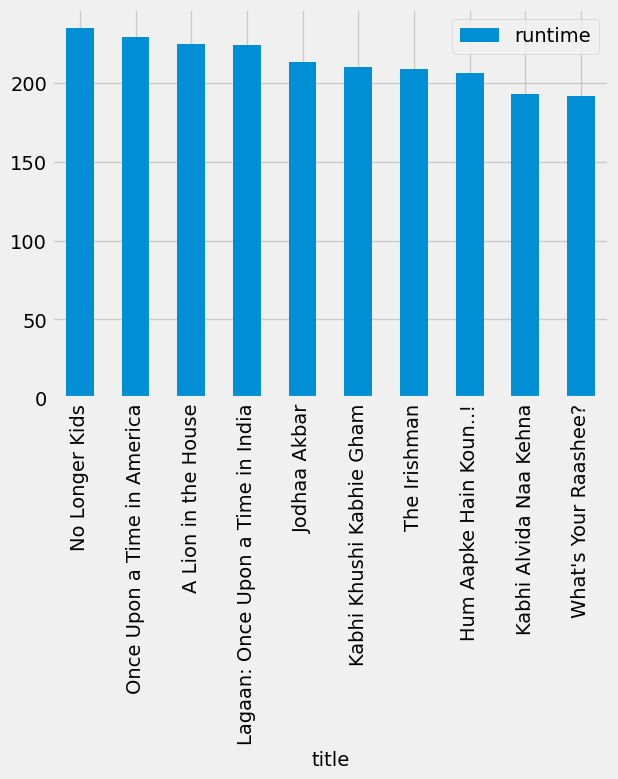

```python
import matplotlib.pyplot as plt
highest_duration.plot.bar(x = 'title', y = 'runtime')
```

**Insights**: The movie "No Longer Kids" is the movie with the longest run time. Most of the movies in the top ten are Bollywood movies and all of the movies in the top ten have a run time of over 190 minutes.

**Query #2**

Which movies had the highest imdb score?

```python
highest_imdb = netflix_movie.sort_values(['imdb_score'], ascending=False).head(10)
highest_imdb
```

|  | index | id | title | type | description | release_year | age_certification | runtime | imdb_id | imdb_score | imdb_votes |
| --- | --- | --- | --- | --- | --- | --- | --- | --- | --- | --- | --- |
| 3172 | 3172 | tm853783 | David Attenborough: A Life on Our Planet | MOVIE | The story of life on our planet by the man who has seen more of the natural world than any other. In more than 90 years, Attenborough has visited every continent on the globe, exploring the wild place… | 2020 | PG | 83 | tt11989890 | 9.0 | 31180.0 |
| 2685 | 2685 | tm432327 | C/o Kancharapalem | MOVIE | From a schoolboy’s crush to a middle-aged bachelor’s office romance, four love stories spanning age, religion and status unfold in a small Indian town. | 2018 | PG | 152 | tt7391996 | 9.0 | 6562.0 |
| 24 | 24 | tm76557 | No Longer Kids | MOVIE | By coincidence, Ahmad discovers that his father, Ramada Al Sokkary has a love letter in his suit case, which reveals his love to a woman other than his mother. Ahmad tries with his brothers and sister… | 1979 | NA | 235 | tt8312792 | 9.0 | 943.0 |
| 822 | 822 | tm166740 | Chhota Bheem & Krishna in Mayanagari | MOVIE | Bheem and his Friends are having a great time in Dwarka with their friend Kanha.Mayandri tries to attack Kanha with some leopards but fails as Kanha fights them off with ease.Bheem gets injured and hi… | 2011 | G | 66 | tt16235600 | 9.0 | 5.0 |
| 246 | 246 | tm92641 | Inception | MOVIE | Cobb, a skilled thief who commits corporate espionage by infiltrating the subconscious of his targets is offered a chance to regain his old life as payment for a task considered to be impossible: "inc… | 2010 | PG-13 | 148 | tt1375666 | 8.8 | 2268288.0 |
| 4143 | 4143 | tm907872 | Sky Tour: The Movie | MOVIE | From the preparations to the performances, this documentary showcases Vietnamese pop idol SÆ¡n Tùng M-TP and the passion behind his Sky Tour concerts. | 2020 | NA | 94 | tt12486200 | 8.8 | 1036.0 |
| 101 | 101 | tm122434 | Forrest Gump | MOVIE | A man with a low IQ has accomplished great things in his life and been present during significant historic events—in each case, far exceeding what anyone imagined he could do. But despite all he has… | 1994 | PG-13 | 142 | tt0109830 | 8.8 | 1994599.0 |
| 495 | 495 | tm25842 | A Lion in the House | MOVIE | Five families struggle with the ups and downs of cancer treatment over the course of six years. | 2006 | NA | 225 | tt0492472 | 8.7 | 312.0 |
| 566 | 566 | tm129763 | Anbe Sivam | MOVIE | Nalla Sivam and Anbarasu meet under different circumstances and their lives are changed as they take the journey of their life. | 2003 | NA | 160 | tt0367495 | 8.7 | 20595.0 |
| 81 | 81 | tm45720 | Bye Bye London | MOVIE | A comedy about an old married man that travels to London with his nephew who does his to save him from exposure to fraud, and being mugged in London, the play also covers some political aspects and pr… | 1982 | NA | 170 | tt10130668 | 8.7 | 154.0 |